# Лабораторная работа №7

Анализ файловой системы Linux. Команды для работы с файлами и каталогами

Ниязов Санджар

2026-03-26

# Цель и задание

**Цель:** ознакомление с файловой системой Linux, приобретение навыков работы с командами для файлов и каталогов.

**Задание:** - Создание, копирование, перемещение файлов и каталогов - Изменение прав доступа (`chmod`) - Анализ файловой системы (`mount`, `df`, `fsck`) - Ответы на контрольные вопросы

# Основные команды для файлов

| Команда | Назначение |
| --- | --- |
| `touch` | создание пустого файла |
| `cp` | копирование файлов/каталогов |
| `mv` | перемещение/переименование |
| `chmod` | изменение прав доступа |
| `mount` | просмотр смонтированных ФС |
| `df -h` | свободное место на дисках |

# Копирование и перемещение

**Копирование:**

```bash
cp file1 file2                    # копирование файла
cp -r dir1 dir2                   # рекурсивное копирование каталога
cp file1 file2 dir/               # копирование нескольких файлов в каталог
```

**Перемещение/переименование:**

```bash
mv file1 file2                    # переименование
mv file dir/                      # перемещение в каталог
```

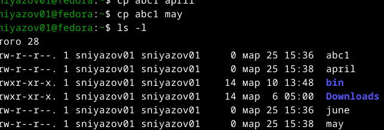

Копирование и перемещение

# Права доступа

**Права:** `r` (чтение), `w` (запись), `x` (выполнение)

**Структура:** `-rwxr-xr--` - `-` – тип (файл) / `d` – каталог - `rwx` – владелец - `r-x` – группа - `r--` – остальные

**Изменение прав:**

```bash
chmod u+x file    # добавить выполнение владельцу
chmod g-w file    # убрать запись у группы
chmod 755 file    # rwxr-xr-x
```

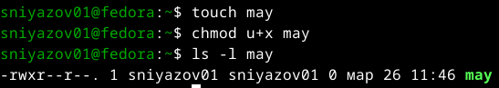

Изменение прав

# Анализ файловой системы

**Просмотр смонтированных ФС:**

```bash
mount | head -10
```

**Свободное место:**

```bash
df -h
```

**Проверка целостности:**

```bash
fsck --help
```

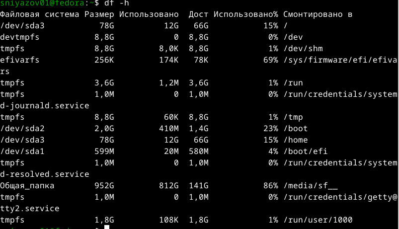

df -h

# Контрольные вопросы (часть 1)

1. **Создание файла:** `touch` – пустой файл; `echo >` или редактор – с содержимым.
2. **Просмотр файла:** `cat` (целиком), `less` (постранично), `head`/`tail` (первые/последние строки).
3. **Копирование в текущем каталоге:** `cp исходный целевой`
4. **Копирование нескольких файлов в каталог:** `cp файл1 файл2 каталог/`
5. **Копирование каталога:** `cp -r исходный целевой`

# Контрольные вопросы (часть 2)

6. **Перемещение файла:** `mv файл каталог/`
7. **Переименование файла:** `mv старое новое`
8. **Команда `mv`:** перемещение и переименование, опция `-i` – подтверждение перезаписи.
9. **Права доступа:** определяют `r`/`w`/`x` для владельца, группы, остальных.  
   Изменяются командой `chmod` (символьно: `u+x`, `g-w`; числово: `755`).

# Результаты работы

**Выполненные операции:** - Создание файлов `abc1`, `april`, `may`, `june` - Копирование в каталог `monthly` - Рекурсивное копирование `monthly.00` - Переименование `april` → `july` - Перемещение файлов и каталогов - Изменение прав доступа (`chmod u+x`, `g-w`, `g+w`) - Анализ ФС (`mount`, `df -h`)

# Выводы

В ходе лабораторной работы освоены:

- Основные команды Linux для работы с файлами и каталогами
- Изменение прав доступа символьным и числовым способом
- Анализ файловой системы (смонтированные ФС, свободное место)

Полученные навыки необходимы для администрирования и эффективной работы в среде Linux.

# Спасибо за внимание!